# Exploring the disproportionality of Canadian parties

I've generated a database of Canadian elections, and I'm curious if there's anything in here that might be of relevance to the discussion of disproportionality.

```python
%matplotlib inline
%run common_variables.py
from IPython.display import display
import pandas as pd
import seaborn as sns
import matplotlib.pyplot as plt
import matplotlib.patches as patches
import math

# Read in dataframe
df1 = pd.read_csv("lop.parl.gc.ca_elections_per_riding/summary.tsv", sep="\t", comment="#")
df2 = pd.read_csv("history-per-year.tsv", sep="\t", comment="#", index_col="Election")
df2["Date"] = pd.to_datetime(df2["Date"])
df1["Date"] = df1["Election"].map(df2["Date"])
df1["Seat %"] = df1["Seats"] / df1.groupby(['Election'])['Seats'].transform(sum)
df1["Vote %"] = df1["Votes"] / df1.groupby(['Election'])['Votes'].transform(sum)
party_colors = pd.read_csv("party-colors.tsv", sep="\t", index_col="Party", comment="~")

# Augment data df1 (Elections by year and party)
df1["Year"] = df1["Date"].map(lambda x: x.year)
df1["Seat % - Vote %"] = df1["Seat %"] - df1["Vote %"]
df1["Seat % / Vote %"] = df1["Seat %"] / df1["Vote %"]
df1["Grouped Color"] = df1["Party"].map(party_colors["Color"]).fillna("grey")
df1n = df1[(df1["Party"] != "Independent") & (df1["Votes"] > 0) & (df1["Seats"] > 0)]

# Augment df2 (Elections by year) with matching df1 data (winning party)
# http://www.elections.ca/content.aspx?section=ele&dir=turn&document=index&lang=e#ftn2
df2["Electors / Population"] = df2["Electors"] / df2["Population"]
df2["Ballots / Population"] = df2["Ballots"] / df2["Population"]
df2["Ballots / Electors"] = df2["Ballots"] / df2["Electors"]
max_seats_per_date = df1.groupby(['Date'])['Seats'].transform(max)
df2 = pd.merge(df2, df1[max_seats_per_date == df1['Seats']], on="Date")

# Display a sample of data
display(df1[(df1["Seats"] > 0) & (df1["Year"] == 2015)].tail(10))
display(df2.tail(2))
```

|  | Election | Party | Candidates | Votes | Seats | Date | Seat % | Vote % | Year | Seat % - Vote % | Seat % / Vote % | Grouped Color |
| --- | --- | --- | --- | --- | --- | --- | --- | --- | --- | --- | --- | --- |
| 458 | 42 | Lib | 338 | 6942937 | 184 | 2015-10-19 | 0.544379 | 0.394676 | 2015 | 0.149702 | 1.379304 | lightcoral |
| 459 | 42 | C | 338 | 5613633 | 99 | 2015-10-19 | 0.292899 | 0.319111 | 2015 | -0.026212 | 0.917860 | cornflowerblue |
| 460 | 42 | N.D.P. | 338 | 3469368 | 44 | 2015-10-19 | 0.130178 | 0.197219 | 2015 | -0.067041 | 0.660066 | sandybrown |
| 461 | 42 | B.Q. | 78 | 821144 | 10 | 2015-10-19 | 0.029586 | 0.046679 | 2015 | -0.017093 | 0.633820 | lightskyblue |
| 462 | 42 | G.P. | 336 | 602933 | 1 | 2015-10-19 | 0.002959 | 0.034274 | 2015 | -0.031316 | 0.086321 | grey |

|  | Date | Population | Electors | Ballots | Electors / Population | Ballots / Population | Ballots / Electors | Election | Party | Candidates | Votes | Seats | Seat % | Vote % | Year | Seat % - Vote % | Seat % / Vote % | Grouped Color |
| --- | --- | --- | --- | --- | --- | --- | --- | --- | --- | --- | --- | --- | --- | --- | --- | --- | --- | --- |
| 40 | 2011-05-02 | 33476688 | 24257592 | 14823408 | 0.724611 | 0.442798 | 0.611083 | 41 | C | 307 | 5835270 | 166 | 0.538961 | 0.396311 | 2011 | 0.142650 | 1.359946 | cornflowerblue |
| 41 | 2015-10-19 | 33476688 | 25939742 | 17711983 | 0.774860 | 0.529084 | 0.682813 | 42 | Lib | 338 | 6942937 | 184 | 0.544379 | 0.394676 | 2015 | 0.149702 | 1.379304 | lightcoral |

## Proportionality indexed on popular vote

If our electoral system was proportional, we'd expect the following to roughly generate a horizontal line with some fuzziness near low popular votes due to rounding of seat assignment. But given Canada's use of FPTP and the [Cube Rule](https://en.wikipedia.org/wiki/Cube_rule), we expect to see significant distortion as a party gains more votes.

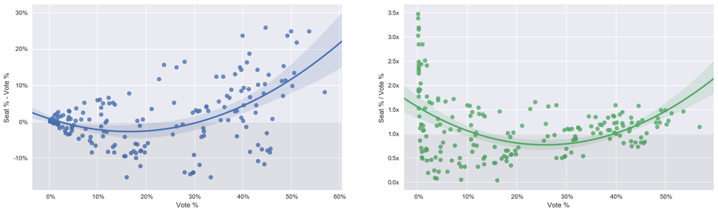

```python
fig, (ax1, ax2) = plt.subplots(ncols=2)
plt.subplots_adjust(left=-1)
sns.regplot(x="Vote %", y="Seat % - Vote %", data=df1n, order=2, ax=ax1)
sns.regplot(x="Vote %", y="Seat % / Vote %", data=df1n, order=2, ax=ax2)
ax1.add_patch(patches.Rectangle((-1, -1), 2, 1, alpha=0.05, facecolor="black"))
ax2.add_patch(patches.Rectangle((-1, -1), 2, 2, alpha=0.05, facecolor="black"))
ax1.set_xticklabels(['{:3.0f}%'.format(x * 100) for x in ax1.get_xticks()])
ax2.set_xticklabels(['{:3.0f}%'.format(x * 100) for x in ax2.get_xticks()])
ax1.set_yticklabels(['{:3.0f}%'.format(y * 100) for y in ax1.get_yticks()])
ax2.set_yticklabels(['{:3.1f}x'.format(y) for y in ax2.get_yticks()]);
```

It's interesting to note the non-linear relation here. Surprisingly, parties with a very low popular vote are better represented than parties with a moderately low popular vote.

## Proportionality indexed on popular vote and party

FPTP tends to favour parties that cluster their support in a smaller number of ridings than parties that spread their support across all ridings. So we'd expect to see unusually high proportionality for the Bloc with respect to their overall popular vote.

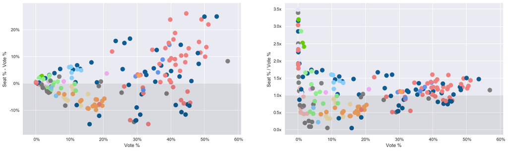

```python
fig, (ax1, ax2) = plt.subplots(ncols=2)
plt.subplots_adjust(left=-1)
df1n.plot(kind="scatter", x="Vote %", y="Seat % - Vote %", c=df1n["Grouped Color"], s=100, ax=ax1)
df1n.plot(kind="scatter", x="Vote %", y="Seat % / Vote %", c=df1n["Grouped Color"], s=100, ax=ax2)
ax1.add_patch(patches.Rectangle((-1, -1), 2, 1, alpha=0.07, facecolor="black"))
ax2.add_patch(patches.Rectangle((-1, -1), 2, 2, alpha=0.07, facecolor="black"));
ax1.set_xticklabels(['{:3.0f}%'.format(x * 100) for x in ax1.get_xticks()])
ax2.set_xticklabels(['{:3.0f}%'.format(x * 100) for x in ax2.get_xticks()])
ax1.set_yticklabels(['{:3.0f}%'.format(y * 100) for y in ax1.get_yticks()])
ax2.set_yticklabels(['{:3.1f}x'.format(y) for y in ax2.get_yticks()]);
```

## Proportionality indexed on era

[Duverger's Law](https://en.wikipedia.org/wiki/Duverger's_law) speaks of a pressure that FPTP exterts on parties. While Canada has yet to collapse into a two-party country, I wonder if there's a change in disproportionality over time.

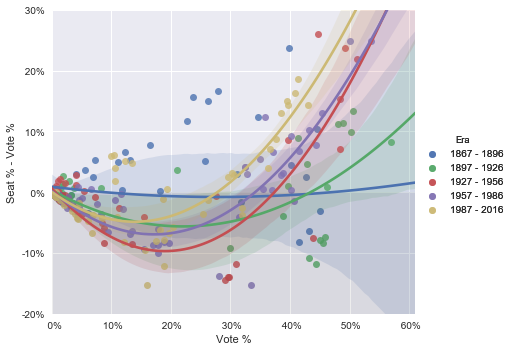

```python
first_year = int(df1["Year"].head(1))
last_year = int(df1["Year"].tail(1))
eras = 5
era_years = math.ceil((last_year - first_year + 1) / eras)
df1["Era"] = df1["Year"].map(lambda x: "{} - {}".format(
    (x - first_year) // era_years * era_years + first_year,
    (x - first_year) // era_years * era_years + first_year + era_years - 1,
))
g = sns.lmplot(x="Vote %", y="Seat % - Vote %", hue="Era", data=df1, order=2)
g.add_legend()
g.set(ylim=(-0.2, 0.3))
g.set(xlim=(0.0, None))
for axlist in g.axes:
    for ax in axlist:
        ax.set_xticklabels(['{:3.0f}%'.format(x * 100) for x in ax.get_xticks()])
        ax.set_yticklabels(['{:3.0f}%'.format(y * 100) for y in ax.get_yticks()])
        ax.add_patch(patches.Rectangle((-1, -1), 2, 1, alpha=0.07, facecolor="black"))
```

Tough to say for sure, but the second-order regression certainly hints at an increase in disproportionality.

## Voter turnout

It's worth noting the the percentage of eligible voters has drastically increased since confederation (see [Election Canada's "A History of the Vote in Canada"](http://www.elections.ca/content.aspx?section=res&dir=his&document=pref&lang=e#al)), most notably in 1920 with The Dominion Elections Act.

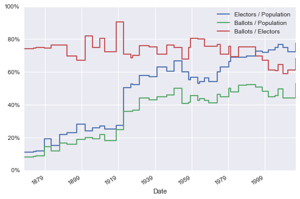

```python
plot = df2.plot(x="Date", y=[
    "Electors / Population",
    "Ballots / Population",
    "Ballots / Electors",
], drawstyle="steps-post")
plot.set(ylim=(0, 1));
plot.set_yticklabels(['{:3.0f}%'.format(y * 100) for y in plot.get_yticks()]);
```

Looking additionally at the percentage of votes that go to any party that wins at least one seat, we can see that Canadians early on learned the importance of strategic voting.

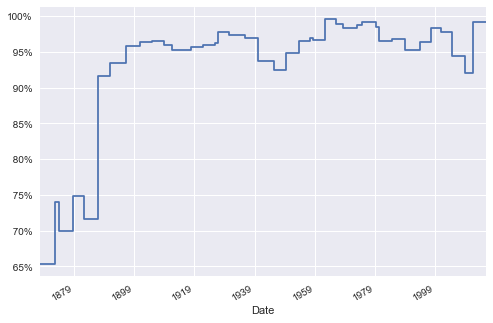

```python
plot = df1n.groupby("Date")["Vote %"].sum().plot(drawstyle="steps-post")
plot.set_yticklabels(['{:3.0f}%'.format(y * 100) for y in plot.get_yticks()]);
```

## False majorities

With the visualization below, we can see instances where the overrepresentation takes the leading party from below to above 50%.

```
42.9% of parliaments between 1867 and 2015 have been false majorities
```

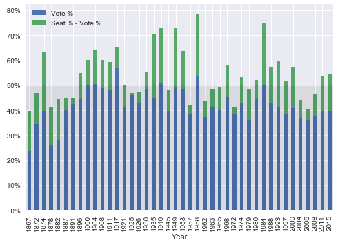

```python
df2["Year"] = df2["Date"].map(lambda x: x.year)
plot = df2.plot(x="Year", y=['Vote %', 'Seat % - Vote %'], kind='bar', stacked=True)
plot.set_yticklabels(['{:3.0f}%'.format(y * 100) for y in plot.get_yticks()]);
plot.add_patch(patches.Rectangle((-1, -1), len(df2) + 1, 1.5, alpha=0.07, facecolor="black"))
print("{:.1f}% of parliaments between {} and {} have been false majorities".format(
    100 * len(df2[(df2["Vote %"] < 0.5) & (df2["Seat %"] > 0.5)]) / len(df2),
    int(df2.head(1)["Year"]),
    int(df2.tail(1)["Year"]),
))
```

## Similarity between the past two elections

It's worth noting the Liberal platform's inclusion of electoral reform while they were significantly underrepresented, and their breaking of that platform policy after winning a significant over representation.

```python
for d in list(df2[df2["Year"] >= 2011]["Date"]):
    parties = df1n[df1n["Date"] == d]
    left = min(parties.T.to_dict().values(), key=lambda p: p["Seat % - Vote %"])
    right = max(parties.T.to_dict().values(), key=lambda p: p["Seat % - Vote %"])
    print("\n".join((
        "{}: {:0.1f}",
        "\t{} won {:0.1f}% of the vote and {:0.1f}% of the seats",
        "\t{} won {:0.1f}% of the vote and {:0.1f}% of the seats",
    )).format(
        d.date(),
        right["Seat % - Vote %"] - left["Seat % - Vote %"],
        left["Party"], left["Vote %"] * 100, left["Seat %"] * 100,
        right["Party"], right["Vote %"] * 100, right["Seat %"] * 100,
    ))
```

```
2011-05-02: 0.2
	Lib won 18.9% of the vote and 11.0% of the seats
	C won 39.6% of the vote and 53.9% of the seats
2015-10-19: 0.2
	N.D.P. won 19.7% of the vote and 13.0% of the seats
	Lib won 39.5% of the vote and 54.4% of the seats
```

## Possible additions to this document

We could replicate the graph style at https://iscanadafair.ca/history-all.html.

```
for key, party in df1.groupby("Party"):
    plt.plot(party["Seat % - Vote %"], drawstyle="steps-post")
plt.show()
```